# Rendimento habitual médio por nível de instrução

Author

Osvaldo Martins Quintella Junior

Published

October 6, 2026

## Introdução

A relação entre o nível de instrução e a remuneração no mercado de trabalho brasileiro é um indicador central para a compreensão da desigualdade e do retorno sobre o investimento em capital humano [Costa et al. (2020); Foguel et al. (2000); Quadlin et al. (2023); Budig et al. (2021); Conwell and Quadlin (2021); ]. Este projeto utiliza microdados da Pesquisa Nacional por Amostra de Domicílios Contínua (PNADc) do IBGE para analisar a evolução do rendimento habitual médio real da população ocupada por nível de instrução. Além disso, foram estimadas equações mincerianas utilizando dados anuais da PNADc com o objetivo de verificar a magnitude do prêmio salarial entre os anos de 2012 e 2025. Todas as estimativas consideram o desenho amostral complexo da pesquisa. Os rendimentos nominais foram deflacionados para uma base de preços constante, permitindo a comparação histórica .

[O script completo desenvolvido em R com a rotina de importação dos dados, limpeza, cálculo dos indicadores e modelagem econométrica a partir dos microdados brutos do IBGE pode ser acessado neste repositório](https://github.com/osvaldoquintellajr/Retorno-medio-habitual-por-nivel-de-instrucao/blob/main/scripts/preparar_dados.R).

```r
#Carregar os pacotes necessários
library(tidyverse)
library(survey)
library(broom)
library(kableExtra)
library(arrow)
```

## Resultados

Abaixo, é possível visualizar a tendência histórica da renda média real segregada pelos níveis de escolaridade. O gráfico ilustra o comportamento do ‘prêmio salarial’ educacional, evidenciando as disparidades de remuneração entre os trabalhadores com ensino superior completo e aqueles com menores níveis de instrução ao longo do tempo.

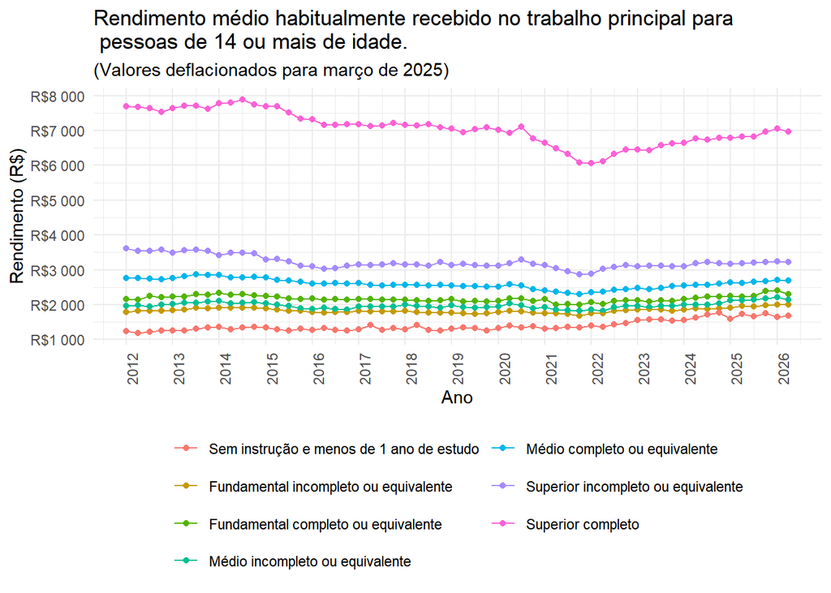

```r
#Criar gráfico de tendência da renda média habitualmente recebida de acordo com o nível de escolaridade.

lista_pnad_completa_rendimento_habitual <- read_parquet("D:/Documentos/github/Retorno-medio-habitual-por-nivel-de-instrucao/lista_pnad_completa_rendimento_habitual.parquet")

lista_pnad_completa_rendimento_habitual <- lista_pnad_completa_rendimento_habitual |> separate(col = chave, into = c("ano", "trimestre"), sep = "_", remove = FALSE, convert = TRUE) |>
  mutate(
    tempo = ano + (trimestre - 1) / 4,
    VD3004 = factor(
      VD3004, levels = c(
      "Sem instrução e menos de 1 ano de estudo",
      "Fundamental incompleto ou equivalente",
      "Fundamental completo ou equivalente",
      "Médio incompleto ou equivalente",
      "Médio completo ou equivalente",
      "Superior incompleto ou equivalente",
      "Superior completo"
      )
    )
  ) |>
  arrange(
    ano, trimestre
  )

ggplot(lista_pnad_completa_rendimento_habitual, mapping = aes(x = tempo, y = VD4016_real, group = VD3004, color = VD3004)) +
  geom_point() +
  geom_line() +
  labs(
    title = "Rendimento médio habitualmente recebido no trabalho principal para\n pessoas de 14 ou mais de idade. ",
    subtitle = "(Valores deflacionados para março de 2025)",
    x = "Ano",
    y = "Rendimento (R$)"
  ) +
  scale_x_continuous(breaks = seq(min(lista_pnad_completa_rendimento_habitual$ano), max(lista_pnad_completa_rendimento_habitual$ano), 1)) +
  scale_y_continuous(
    breaks = seq(floor(min(lista_pnad_completa_rendimento_habitual$VD4016_real)/1000) * 1000, ceiling(max(lista_pnad_completa_rendimento_habitual$VD4016_real)/1000) * 1000
, 1000), labels = scales::number_format(prefix = "R$")
) +
  theme_minimal() +
  theme(
    axis.text.x = element_text(angle = 90),
    legend.position = "bottom",
    legend.spacing.y = unit(0.01, "cm"),
    legend.title = element_blank(),
    text = element_text(size = 11)
  ) +
  guides(
    color = guide_legend(ncol = 2)
  )
```

```r
rm(lista_pnad_completa_rendimento_habitual)

invisible(gc())
```

Observa-se que os trabalhadores com ensino superior, em média, recebem salários mais elevados em comparação com os indivíduos que não possuem ensino superior completo. Nota-se também uma queda no prêmio salarial ao longo dos anos. Resta saber se essa associação é estatísticamente significativa e se persiste quando controlamos por outras características do trabalhador? A Tabela 1 apresenta os coeficientes estimados que capturam a associação entre ter ensino superior completo e o logaritmo do rendimento habitual médio, controlando por idade, sexo, cor/raça, setor de atividade e unidade da federação.

```r
coeficientes <- read_parquet("D:/Documentos/github/Retorno-medio-habitual-por-nivel-de-instrucao/pnad_completa_coeficientes.parquet")

premio <- coeficientes |>
  filter(term == "Ensino_superiorSuperior_completo") |>
  mutate(
    premio_perc = (exp(estimate) - 1) * 100,
    premio_perc_low = (exp(conf.low) - 1) * 100,
    premio_perc_high = (exp(conf.high) - 1) * 100,
  ) |>
  select(ano, estimate, std.error, conf.low, conf.high,
         premio_perc, premio_perc_low, premio_perc_high) |>
  arrange(ano)

variacao_2025 <- premio |>
  filter(ano == 2025) |>
  mutate(
    var_pp = premio_perc - premio |> filter(ano == 2012) |> pull(premio_perc),
    var_log = estimate - premio |> filter(ano == 2012) |> pull(estimate)
  )

premio |>
  transmute(
    Ano = ano,
    Coef = round(estimate, 4),
    EP = round(std.error, 4),
    `IC 95% (inf.)` = round(conf.low, 4),
    `IC 95% (sup.)` = round(conf.high, 4),
    `Prêmio (%)` = round(premio_perc, 2),
    `Prêmio IC (inf.)` = round(premio_perc_low, 2),
    `Prêmio IC (sup.)` = round(premio_perc_high, 2)
    )  |>
  kbl(
    caption = "Tabela 1: Estimativas do coeficiente do prêmio salarial para o ensino superior (2012-2025)",
    align = "c"
  ) |>
  kable_styling(
    bootstrap_options = c("striped"),
    full_width = FALSE
  ) |>
  column_spec(1, width = "2cm") |>
  column_spec(2:8, width = "2cm")
```

Tabela 1: Estimativas do coeficiente do prêmio salarial para o ensino superior (2012-2025)

| Ano | Coef | EP | IC 95% (inf.) | IC 95% (sup.) | Prêmio (%) | Prêmio IC (inf.) | Prêmio IC (sup.) |
| --- | --- | --- | --- | --- | --- | --- | --- |
| 2012 | 0.9398 | 0.0109 | 0.9182 | 0.9613 | 155.94 | 150.48 | 161.51 |
| 2013 | 0.9356 | 0.0110 | 0.9138 | 0.9574 | 154.87 | 149.38 | 160.48 |
| 2014 | 0.9336 | 0.0113 | 0.9113 | 0.9558 | 154.36 | 148.75 | 160.09 |
| 2015 | 0.8910 | 0.0126 | 0.8661 | 0.9160 | 143.76 | 137.75 | 149.92 |
| 2016 | 0.9133 | 0.0137 | 0.8863 | 0.9403 | 149.25 | 142.61 | 156.08 |
| 2017 | 0.8842 | 0.0129 | 0.8587 | 0.9096 | 142.10 | 136.02 | 148.34 |
| 2018 | 0.8673 | 0.0121 | 0.8435 | 0.8911 | 138.06 | 132.45 | 143.79 |
| 2019 | 0.8640 | 0.0100 | 0.8444 | 0.8837 | 137.27 | 132.65 | 141.98 |
| 2022 | 0.8297 | 0.0095 | 0.8109 | 0.8485 | 129.25 | 124.98 | 133.61 |
| 2023 | 0.8196 | 0.0099 | 0.8000 | 0.8392 | 126.96 | 122.55 | 131.46 |
| 2024 | 0.7947 | 0.0090 | 0.7769 | 0.8125 | 121.37 | 117.46 | 125.35 |
| 2025 | 0.7995 | 0.0096 | 0.7806 | 0.8183 | 122.43 | 118.28 | 126.67 |

**Note**

**Nota:** A variável dependente é o logaritmo da renda habitual (preços médios de 2025, deflator CO2). Controles: idade, idade², sexo, setor de atividade, unidade da federação e cor/raça (coeficientes omitidos). Cada linha é um modelo estimado separadamente para o ano.

Os resultados apresentados na tabela 1 confirmam o que se verifica no gráfico anterior. De fato, em 2012, o prêmio salarial para quem tem ensino superior - controlando por idade, sexo, cor/raça, setor de atividade e unidade da federação - é 155.94%. Entretanto, esse prêmio salarial varia ao longo do tempo. Verifica-se uma queda do prêmio salarial substancial: em 2025, o prêmio é de 122.43%, uma redução de -33.5 pontos percentuais em relação a 2012.

## Referências Bibliográficas

Budig, Michelle J., Misun Lim, and Melissa J. Hodges. 2021. “Racial and Gender Pay Disparities: The Role of Education.” *Social Science Research* 98 (August): 102580. https://doi.org/10.1016/j.ssresearch.2021.102580.

Conwell, Jordan A, and Natasha Quadlin. 2021. “Race, Gender, Higher Education, and Socioeconomic Attainment: Evidence from Baby Boomers at Midlife.” *Social Forces* 100 (3): 990–1024. https://doi.org/10.1093/sf/soab010.

Costa, Joana Simões de Melo, Fernando Gaiger, Bruna de Souza Azevedo, Sandro Sacchet de Carvalho, and Ana Luiza Neves de Holanda Barbosa. 2020. *Heterogeneidade Do Diferencial Salarial público-Privado*.

Foguel, Miguel N, Indermit Gill, Rosane Mendonça, and Ricardo Paes de Barros. 2000. “The Public-Private Wage Gap in Brazil.” *Revista Brasileira de Economia* 54 (4): 433–72.

Quadlin, Natasha, Tom VanHeuvelen, and Caitlin E. Ahearn. 2023. “Higher Education and High-Wage Gender Inequality.” *Social Science Research* 112 (May): 102873. https://doi.org/10.1016/j.ssresearch.2023.102873.